# kadai5

### A1-2-2.lm関数

Ref1からの例題をlm関数で確認する

その結果

EstimateはInterceptとaについての推定値、Pr(>|t|)は0.1%水準で有意だった(***)

degrees of freedom自由度は13でありデータ数15から2を引いた数となっている。

Multiple R-squared決定係数は0.991。データの変動のうち回帰モデルによって説明できる割合を示す。

```r
reidai <-lm(b~a) #モデル式.目的変数~説明変数
summary(reidai) #結果を見る。
```

```
##
## Call:
## lm(formula = b ~ a)
##
## Residuals:
##     Min      1Q  Median      3Q     Max
## -1.7333 -1.1333 -0.3833  0.7417  3.1167
##
## Coefficients:
##              Estimate Std. Error t value Pr(>|t|)
## (Intercept) -87.51667    5.93694  -14.74 1.71e-09 ***
## a             3.45000    0.09114   37.85 1.09e-14 ***
## ---
## Signif. codes:  0 '***' 0.001 '**' 0.01 '*' 0.05 '.' 0.1 ' ' 1
##
## Residual standard error: 1.525 on 13 degrees of freedom
## Multiple R-squared:  0.991,  Adjusted R-squared:  0.9903
## F-statistic:  1433 on 1 and 13 DF,  p-value: 1.091e-14
```

```r
reidai.coef<-coef(reidai) #簡単な結果だけを見る。
reidai.coef
```

```
## (Intercept)           a
##   -87.51667     3.45000
```

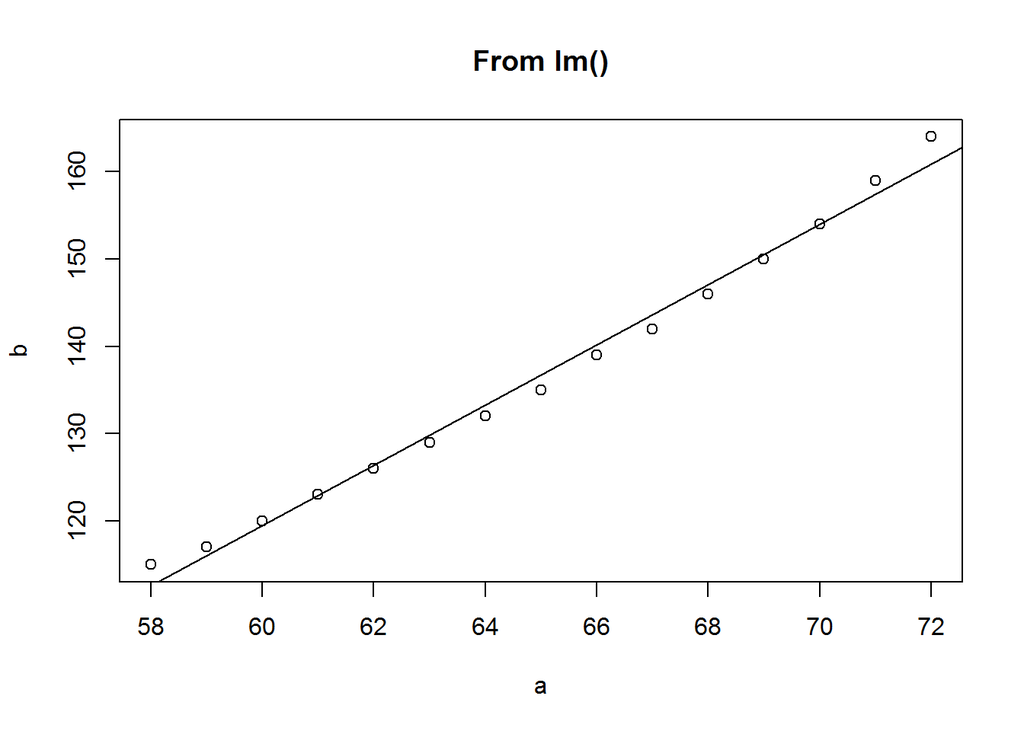

```r
plot(a,b,main="From lm()")
abline(reidai$coef[1],reidai$coef[2])　#aに切片を、bに傾きを指定する。
```

lm() ： 線形モデルによる回帰を行う

Ref.2 http://cse.naro.affrc.go.jp/takezawa/r-tips/r/71.html

```r
reidai2 <-lm(b~a) #モデル式.目的変数~説明変数
summary(reidai2) #結果を見る。
```

```
##
## Call:
## lm(formula = b ~ a)
##
## Residuals:
##     Min      1Q  Median      3Q     Max
## -1.7333 -1.1333 -0.3833  0.7417  3.1167
##
## Coefficients:
##              Estimate Std. Error t value Pr(>|t|)
## (Intercept) -87.51667    5.93694  -14.74 1.71e-09 ***
## a             3.45000    0.09114   37.85 1.09e-14 ***
## ---
## Signif. codes:  0 '***' 0.001 '**' 0.01 '*' 0.05 '.' 0.1 ' ' 1
##
## Residual standard error: 1.525 on 13 degrees of freedom
## Multiple R-squared:  0.991,  Adjusted R-squared:  0.9903
## F-statistic:  1433 on 1 and 13 DF,  p-value: 1.091e-14
```

```r
reidai.coef2<-coef(reidai2) #簡単な結果だけを見る。
reidai.coef2
```

```
## (Intercept)           a
##   -87.51667     3.45000
```

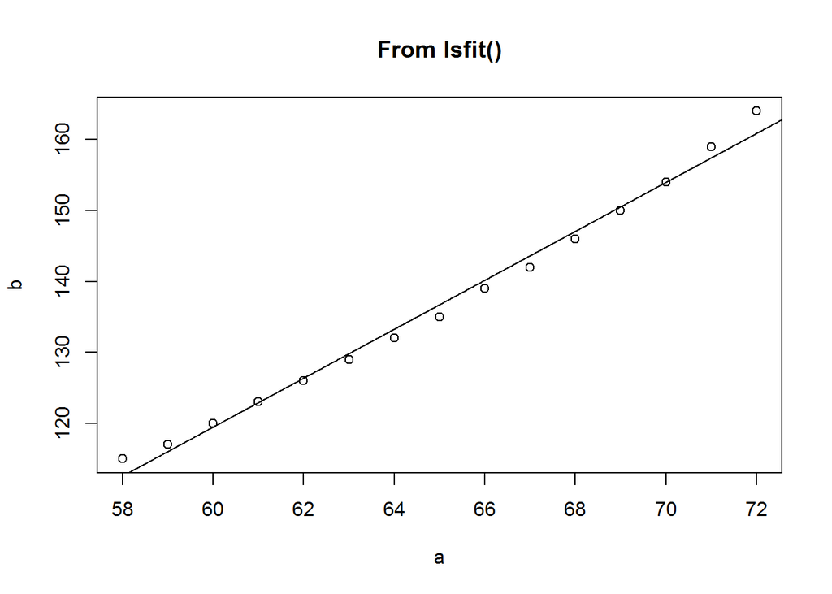

```r
plot(a,b,main="From lsfit()")
abline(reidai2$coef[1],reidai2$coef[2])　#aに切片を、bに傾きを指定する。
```

# Q2.

Read “Systems of Linear Equations with Matrix 行列で連立方程式” and “PCA with Matrix 行列でPCA” before the class on May 22.

### A2.

はい